# CCMnet: Congruence Class Models for Networks

> **Model Specification**: Defining the network properties of interest and their corresponding probability distributions.

> **MCMC Sampling**: Generate a representative ensemble of networks, but only return the network statistics (not entire networks).

> **Verification and Diagnostics**: Assessing the sampler’s performance and validating that the generated network statistics align with the specified theoretical targets.

> **Create Network Ensemble for Analysis** : Once the sampler is validated, one can generate an emsemble of networks for analysis.

# Section 1: Edge Count Sampler Verification

This section verifies that the CCM sampler correctly reproduces networks according to specified edge-count distributions. In a CCM, the probability of sampling a network with $k$ edges is defined by the probability assigned to the congruence class consisting of all networks with exactly $k$ edges. The sampler then assigns equal probability to each individual network within that class.

## Example 1.1: Poisson Edge Count

We fit a CCM where the **number of edges** follows a Poisson distribution with $\lambda = 350$. The probability of sampling a network with k edges is given by the Poisson mass function:

$$P(K=k) = \frac{\lambda^k
e^{-\lambda}}{k!}$$

```r
ccm_sample <- sample_ccm(
  network_stats = list("edges"),
  prob_distr = list("poisson"),
  prob_distr_params = list(list(350)),
  population = 50
)

summary(ccm_sample)
```

```
## Summary of ccm_sample object
## -------------------------
##
## Statistic:  edges
##    Min. 1st Qu.  Median    Mean 3rd Qu.    Max.
##   286.0   337.0   349.0   349.8   363.0   420.0
```

```r
print(ccm_sample)
```

```
## Object of class 'ccm_sample'
## -------------------------
## Statistics:        edges
## Distribution(s):   poisson
## Population:        50
## MCMC samples:      1000 rows x 1 cols
```

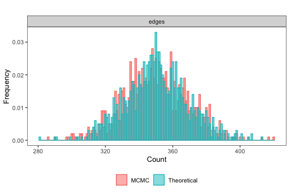

```r
# Compare MCMC samples to theoretical Poisson distribution
ccm_sample<- CCM_theoretical_check(ccm_sample, n_sim = 1000)

# Plot density with theoretical distribution
plot(ccm_sample, stats = "edges", type = "hist", include_theoretical = TRUE)
```

## Example 1.2: Uniforn

We fit a CCM where the **number of edges** follows a uniform distribution.

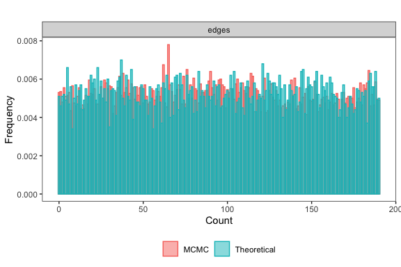

```r
ccm_sample <- sample_ccm(
  network_stats = list("edges"),
  prob_distr = list("uniform"),
  prob_distr_params = list(list(0)),
  population = 20,
  sample_size = 20000L,
  burnin = 100000L,
  interval = 1000L,
)

ccm_sample<- CCM_theoretical_check(ccm_sample, n_sim = 10000)
plot(ccm_sample, stats = "edges", type = "hist", include_theoretical = TRUE)
```

> **Explanation:** The density plot verifies that CCM samples uniformly reproduce all possible edge counts.

## Example 1.3: Non-Parametric

Arbitrary edge count distributions can be specified using the non-parametric (“NP”) option. This direct control over congruence class probabilities allows for stable simulation even under non-standard structural priors.

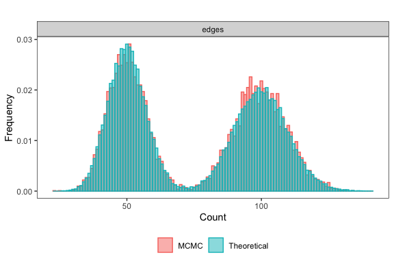

```r
n_max <- choose(50, 2)
alpha <- dpois(0:n_max, lambda = 50) + dpois(0:n_max, lambda = 100)
prob_distr_params <- alpha / sum(alpha)

ccm_sample <- sample_ccm(
  network_stats = list("edges"),
  prob_distr = list("np"),
  prob_distr_params = list(list(prob_distr_params)),
  population = 50L,
  sample_size = 10000L,
  burnin = 100000L
)

ccm_sample<- CCM_theoretical_check(ccm_sample, n_sim = 50000)
plot(ccm_sample, stats = "edges", type = "hist", include_theoretical = TRUE)
```

# Section 2: Degree Distribution Sampler Verification

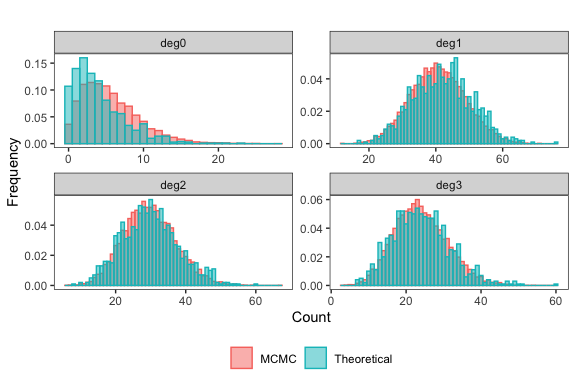

```r
ccm_sample<- sample_ccm(network_stats='DegreeDist',
                        prob_distr='DirMult',
                        prob_distr_params=list(list(c(2,21,15,12))),
                        population = 100L,
                        sample_size = 10000L,
                        burnin=100000L,
                        interval=1000L)

ccm_sample <- CCM_theoretical_check(ccm_sample, n_sim = 1000)
plot(ccm_sample,
     stats = paste0("deg", 0:3),
     type = "hist",
     include_theoretical = TRUE
)
```

# Section 3: Degree Mixing and Triangle

This section illustrates the sampler for models involving higher-order dependencies. In this example, a multivariate normal constraint is placed on the degree mixing matrix and a univariate normal constraint is placed on the triangle count. Because the degree mixing matrix effectively determines the number of connected triples, the simultaneous constraint on triangle counts implicitly influences the network’s global clustering coefficient.

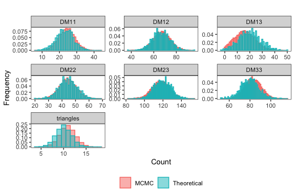

```r
mean_vec = c(23, 66, 44, 20, 120, 80)
var_mat = matrix(data = c(22, -3, -2, -5, -6, -4,
                          -3, 58, -7, -14, -18, -12,
                          -2, -7, 41, -9, -12, -8,
                          -5, -14, -9, 75, -25, -17,
                          -6, -18, -12, -25, 89, -22,
                          -4, -12, -8, -17, -22, 68), ncol = 6)
prob_distr_params = list(list(mean_vec, var_mat),
                         list(10,3))

ccm_sample <- sample_ccm(network_stats=c('DegMixing', 'Triangles'),
                         prob_distr=c('Normal', 'Normal'),
                         prob_distr_params=prob_distr_params,
                         sample_size = 10000L,
                         burnin=100000L,
                         interval=1000L,
                         population=500L)

ccm_sample <- CCM_theoretical_check(ccm_sample, n_sim = 1000)
plot(ccm_sample,
     stats = c("DM11", "DM12", "DM13", "DM22", "DM23", "DM33", "triangles"),
     type = "hist",
     include_theoretical = TRUE)
```

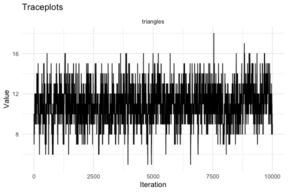

```r
CCM_traceplot(ccm_sample, stats = "triangles")
```

# Section 4: Illustration

A primary use case for CCMnet is generating network ensembles that reflect the uncertainty in properties estimated from empirical data. These examples demonstrate how uncertainty induced by different sampling designs is explicitly propagated into the predictive network ensembles.

> **Posterior Predictive for a New School**: This illustrates whole-network sampling, where uncertainty arises from heterogeneity across multiple distinct populations (e.g., different high schools).

> **Posterior Predictive for a Sampled School**: This demonstrates individual-level sampling, where uncertainty arises from the partial observation of nodes and edges within a single population.

By comparing CCMnet to standard benchmarks like ERGMs, we can evaluate how well the model captures both population-level heterogeneity and sampling-induced uncertainty.

# Section 4.1: Data

```r
utils::data("faux.mesa.high", package = "ergm", envir = environment())
utils::data("faux.desert.high", package = "ergm", envir = environment())
utils::data("faux.dixon.high", package = "ergm", envir = environment())
utils::data("faux.magnolia.high", package = "ergm", envir = environment())

mesa_net = intergraph::asIgraph(faux.mesa.high)
desert_net = intergraph::asIgraph(faux.desert.high)
dixon_net = intergraph::asIgraph(faux.dixon.high)
magnolia_net = intergraph::asIgraph(faux.magnolia.high)

# Create summary table
hs_summary <- data.frame(
  High_School = c("Mesa High", "Desert High", "Dixon High", "Magnolia High"),
  Nodes = c(
    igraph::vcount(mesa_net),
    igraph::vcount(desert_net),
    igraph::vcount(dixon_net),
    igraph::vcount(magnolia_net)
  ),
  Edges = c(
    igraph::gsize(mesa_net),
    igraph::gsize(desert_net),
    igraph::gsize(dixon_net),
    igraph::gsize(magnolia_net)
  )
)

# Render table
kableExtra::kable(
  hs_summary,
  caption = "Summary of high school friendship networks from the ERGM package"
)
```

Summary of high school friendship networks from the ERGM package

| High_School | Nodes | Edges |
| --- | --- | --- |
| Mesa High | 205 | 203 |
| Desert High | 107 | 439 |
| Dixon High | 248 | 1197 |
| Magnolia High | 1461 | 974 |

# 4.2 Posterior Predictive for a New School

This section illustrates whole-network sampling, where uncertainty arises from heterogeneity across multiple distinct populations (e.g., different high schools).

## 4.2.1 Posterior Distribution for Edge Propensity

```r
#Normal
densities <- hs_summary$Edges / choose(hs_summary$Nodes, 2)
sigma <- sd(densities)
prior <- RBesT::mixnorm(c(1, 0.5, 1), sigma = sigma)
post_normal <- RBesT::postmix(prior, m = mean(densities), n = length(densities))
```

## 4.2.2 Generation of Network Statistics for CCM, ERGM, and G(n,m)

```r
population = 100
n_samples = 10000L

#CCM
ccm_sample <- sample_ccm(
  network_stats = list("Density"),
  prob_distr = list("Normal"),
  prob_distr_params = list(list(post_normal[2], (post_normal[3])^2)),
  population = population,
  sample_size = n_samples,
  burnin = 100000L,
  interval = 1000L,
)

#ERGM
net <- network::network(population,
                        directed = FALSE)
ergm_sample <- simulate(net ~ edges,
                        coef = log(post_normal[2] / (1 - post_normal[2])),
                        nsim = n_samples,
                        output = "stats") / choose(population, 2)

#G(n,m)
m_edges = round(post_normal[2]*choose(population, 2))
er_gnm_list <- replicate(n_samples,
                         igraph::sample_gnm(n = population, m = m_edges, directed = FALSE),
                         simplify = FALSE)
er_gnm_stats <- sapply(er_gnm_list, igraph::ecount)
er_gnm_sample <- er_gnm_stats / choose(population, 2)
```

## 4.2.3 Density Plot of Network Statistics for CCM, ERGM, and G(n,m)

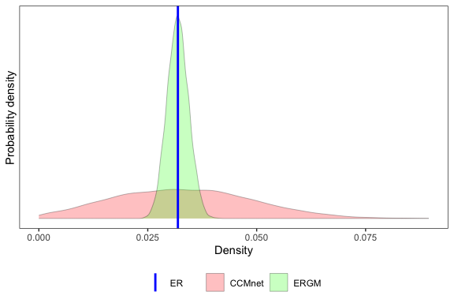

```r
Network_samples <- data.frame(
  value = c(ccm_sample$mcmc_stats$density, ergm_sample, er_gnm_sample),
  model = c(rep("CCMnet", n_samples), rep("ERGM", n_samples), rep("ER", n_samples))
)

ggplot2::ggplot( Network_samples %>% filter(model != "ER"),
                 aes(x = value, fill = model)
) +
  geom_density(alpha = 0.25, linewidth = .1) +
  geom_vline(
    aes(xintercept = er_gnm_sample[1], colour = "ER"),
    linewidth = 1,
    linetype = "solid"
  ) +
  scale_fill_manual(
    values = c(CCMnet = "red", ERGM = "green")
  ) +
  scale_colour_manual(
    values = c(ER = "blue")
  ) +
  labs(x = "Density", y = "Probability density", fill = "Model", colour = "Model") +
  theme_bw() +
  theme(legend.position = "bottom",
        legend.title = element_blank(),
        panel.grid.major = element_blank(),
        panel.grid.minor = element_blank(),
        axis.text.y = element_blank(),
        axis.ticks.y = element_blank())
```

# Posterior Predictive Network Statistics and Ensembles for Sampled School

## 4.3.1 Generation of Posterior Predictive Network Statistics for Sampled School for CCM, ERGM, and G(n,m)

```r
res = data.frame(model = NULL,
                 value = NULL)


dixon_deg = igraph::degree(dixon_net)
prior.unif <- RBesT::mixbeta(c(1, 1, 1))
N = igraph::vcount(dixon_net)

n_samples <- 1000L

for (num_sample_nodes in seq(40,240,40)) {
  dixon_deg_sample = sample(x = dixon_deg, size = num_sample_nodes, replace = FALSE)

  r=sum(dixon_deg_sample)
  n=sum(num_sample_nodes*(N-1))
  posterior.sum_beta <- RBesT::postmix(prior.unif,
                                       n=n,
                                       r=r)

  alpha_post <- posterior.sum_beta[2]
  beta_post  <- posterior.sum_beta[3]

  # Infinite-population variance
  var_inf <- (alpha_post * beta_post) /
    ((alpha_post + beta_post)^2 * (alpha_post + beta_post + 1))

  # Finite population correction
  fpc <- (N - num_sample_nodes) / (N - 1)
  var_fpc <- var_inf * fpc

  # Moment-matched Beta parameters
  mu <- alpha_post / (alpha_post + beta_post)
  S <- mu * (1 - mu) / var_fpc - 1
  posterior.sum_beta[2] <- mu * S
  posterior.sum_beta[3] <- (1 - mu) * S

  ccm_sample <- sample_ccm(
    network_stats = list("Density"),
    prob_distr = list("Beta"),
    prob_distr_params = list(list(posterior.sum_beta[2], posterior.sum_beta[3])),
    population = N,
    sample_size = n_samples,
    burnin = 100000L
  )

  res = bind_rows(res, data.frame(
    model = rep("CCMnet", length(ccm_sample$mcmc_stats$density)),
    value = ccm_sample$mcmc_stats$density,
    sample = num_sample_nodes))

  net <- network::network(N, directed = FALSE)
  p = posterior.sum_beta[2]/(posterior.sum_beta[2] + posterior.sum_beta[3])
  theta = log(p / (1-p))

  ERGM <- simulate(
    net ~ edges,
    coef = theta,
    nsim = n_samples,
    output = "stats"
  ) / choose(N, 2)

  ER = rep(posterior.sum_beta[2]/(posterior.sum_beta[2] + posterior.sum_beta[3]), n_samples)

  res <- bind_rows(res, data.frame(
    value = c(ERGM, ER),
    model = c(rep("ERGM", n_samples), rep("ER", n_samples)),
    sample = c(rep(num_sample_nodes, n_samples), rep(num_sample_nodes, n_samples))
  ))

}
```

## 4.3.2 Plot of Posterior Predictive Network Statistics for Sampled School for CCM, ERGM, and G(n,m)

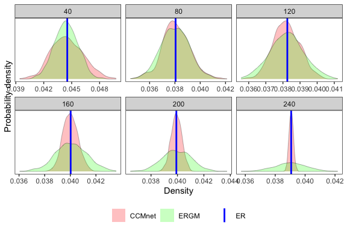

```r
# ER vertical lines
ER_lines <- res %>%
  filter(model == "ER") %>%
  group_by(sample, model) %>%
  summarise(xintercept = unique(value), .groups = "drop")

ggplot2::ggplot(
  res %>% filter(model != "ER"),
  aes(x = value, fill = model)
) +
  geom_density(alpha = 0.25, linewidth = .1) +

  # ER vertical lines
  geom_vline(
    data = ER_lines,
    aes(xintercept = xintercept, colour = model),
    linetype = "solid",
    linewidth = 1
  ) +

  scale_fill_manual(
    values = c(
      CCMnet = "red",
      ERGM   = "green"
    )
  ) +
  scale_colour_manual(
    values = c(
      ER = "blue"
    )
  ) +

  labs(
    x = "Density",
    y = "Probability density",
    fill = "Model",
    colour = NULL
  ) +

  guides(
    colour = guide_legend(override.aes = list(fill = NA)),
    fill   = guide_legend(override.aes = list(colour = NA))
  ) +

  theme_bw() +
  theme(legend.position = "bottom",
        legend.title = element_blank(),
        panel.grid.major = element_blank(),
        panel.grid.minor = element_blank(),
        axis.text.y = element_blank(),
        axis.ticks.y = element_blank()) +
  facet_wrap(~sample, scales =  "free")
```

```r
ccm_sample <- sample_ccm(
  network_stats = list("Density"),
  prob_distr = list("Normal"),
  prob_distr_params = list(list(post_normal[2], (post_normal[3])^2)),
  population = 100L,
  sample_size = 10000L,
  burnin = 100000L
)

school_ensemble <- sample_ccm(
  network_stats = list("Density"),
  prob_distr = list("Normal"),
  prob_distr_params = list(list(post_normal[2], (post_normal[3])^2)),
  population = 100L,
  sample_size = 10L,
  burnin = 1L,
  interval = 1000L,
  initial_g = ccm_sample$g[[1]],
  use_initial_g = TRUE,
  stats_only = FALSE)

class(school_ensemble$g)
```

```
## [1] "list"
```

```r
length(school_ensemble$g)
```

```
## [1] 10
```

```r
class(school_ensemble$g[[1]])
```

```
## [1] "igraph"
```